# 北单 Niche Analysis — Bayesian Stratified Edge Search

Generated 2026-05-02T22:36:51 · sources: `data/beidan_history.db` + `data/raw/beidan_history_user.csv`

## 1. Methodology

Each historical match contributes 3 binary observations (one per option ∈ {3,1,0}). For each option we compute an implied probability by de-vigging the avg-EU 1X2 odds (proportional method as primary; power method for sensitivity). We then enumerate ~hundreds of *niches* — strata defined by 1-, 2-, and 3-way combinations of `option_type`, `handicap_class`, `option_strength`, `league_tier`, `prob_bucket`.

For each niche we fit a Beta-Binomial posterior with prior mean = mean implied prob in the niche and concentration κ=100. The primary inclusion filter is **P(true_p × SP_proxy × 0.65 > 1.05) ≥ 0.7**: a distribution-aware threshold that incorporates niche-level uncertainty. SP proxy is the empirical median `winning_sp` in the niche when ≥10 wins exist, else `mean(eu_odds) × 0.65 / 0.95`.

## 2. Sample sizes

#### Total matches

37,823

DB + user CSV after dedupe

#### Match-option observations

113,469

3 options per match

#### Train / Test (split by issue)

83,667 / 29,802

first 100 issues = train

#### Niches scored (n≥50, k≥5)

533

1/2/3-way feature crosses

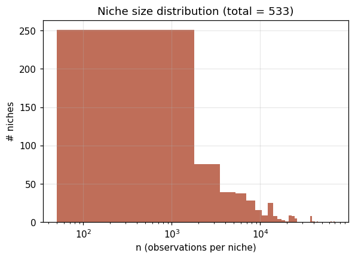

## 3. Global calibration

If avg-EU is well-calibrated, points should fall on the 45° line.

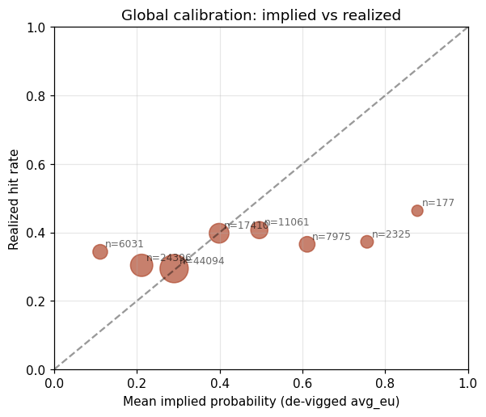

#### Niches passing on FULL data

4

of 533 scored

#### Niches passing on TRAIN

6

used for OOS validation

| Stratum | Dims | n | k | Implied | Hit | Post μ | P05 | P95 | P(EV>1.05) | EV pt | SP proxy | binom p |
| --- | --- | --- | --- | --- | --- | --- | --- | --- | --- | --- | --- | --- |
| option_type=3, league_tier=Other, prob_bucket=>.85 | option_type\|league_tier\|prob_bucket | 75 | 43 | 0.885 | 0.573 | 0.751 | 0.696 | 0.803 | 0.92 | 0.853 | 2.290 | 1 |
| option_type=0, handicap_class=h2plus, prob_bucket=.55-.70 | option_type\|handicap_class\|prob_bucket | 96 | 29 | 0.673 | 0.302 | 0.491 | 0.433 | 0.550 | 0.91 | 0.717 | 3.650 | 1 |
| handicap_class=h2plus, league_tier=Other, prob_bucket=.55-.70 | handicap_class\|league_tier\|prob_bucket | 124 | 28 | 0.671 | 0.226 | 0.424 | 0.371 | 0.479 | 0.89 | 0.618 | 4.210 | 1 |
| option_type=3, league_tier=LowerEU, prob_bucket=>.85 | option_type\|league_tier\|prob_bucket | 60 | 27 | 0.870 | 0.450 | 0.712 | 0.652 | 0.770 | 0.86 | 0.702 | 2.400 | 1 |
| option_strength=fav, league_tier=Other, prob_bucket=>.85 | option_strength\|league_tier\|prob_bucket | 90 | 48 | 0.885 | 0.533 | 0.719 | 0.664 | 0.771 | 0.59 | 0.787 | 2.270 | 1 |
| league_tier=Other, prob_bucket=>.85 | league_tier\|prob_bucket | 90 | 48 | 0.885 | 0.533 | 0.719 | 0.664 | 0.771 | 0.59 | 0.787 | 2.270 | 1 |
| handicap_class=h2plus, league_tier=Other, prob_bucket=>.85 | handicap_class\|league_tier\|prob_bucket | 90 | 48 | 0.885 | 0.533 | 0.719 | 0.664 | 0.771 | 0.59 | 0.787 | 2.270 | 1 |
| league_tier=LowerEU, prob_bucket=>.85 | league_tier\|prob_bucket | 63 | 28 | 0.869 | 0.444 | 0.705 | 0.645 | 0.762 | 0.56 | 0.666 | 2.305 | 1 |
| option_strength=fav, league_tier=LowerEU, prob_bucket=>.85 | option_strength\|league_tier\|prob_bucket | 63 | 28 | 0.869 | 0.444 | 0.705 | 0.645 | 0.762 | 0.56 | 0.666 | 2.305 | 1 |
| handicap_class=h2plus, league_tier=LowerEU, prob_bucket=>.85 | handicap_class\|league_tier\|prob_bucket | 63 | 28 | 0.869 | 0.444 | 0.705 | 0.645 | 0.762 | 0.56 | 0.666 | 2.305 | 1 |
| handicap_class=h2plus, league_tier=LowerEU, prob_bucket=.55-.70 | handicap_class\|league_tier\|prob_bucket | 160 | 37 | 0.676 | 0.231 | 0.402 | 0.353 | 0.453 | 0.09 | 0.549 | 3.650 | 1 |
| option_type=3, handicap_class=h2plus, prob_bucket=.55-.70 | option_type\|handicap_class\|prob_bucket | 218 | 46 | 0.675 | 0.211 | 0.357 | 0.313 | 0.401 | 0.09 | 0.564 | 4.110 | 1 |
| option_type=0, league_tier=LowerEU, prob_bucket=.70-.85 | option_type\|league_tier\|prob_bucket | 208 | 80 | 0.747 | 0.385 | 0.502 | 0.455 | 0.549 | 0.01 | 0.711 | 2.845 | 1 |
| option_type=3, prob_bucket=>.85 | option_type\|prob_bucket | 159 | 76 | 0.877 | 0.478 | 0.632 | 0.582 | 0.681 | 0.01 | 0.713 | 2.295 | 1 |
| option_type=3, option_strength=fav, prob_bucket=>.85 | option_type\|option_strength\|prob_bucket | 159 | 76 | 0.877 | 0.478 | 0.632 | 0.582 | 0.681 | 0.01 | 0.713 | 2.295 | 1 |
| option_type=3, handicap_class=h2plus, prob_bucket=>.85 | option_type\|handicap_class\|prob_bucket | 159 | 76 | 0.877 | 0.478 | 0.632 | 0.582 | 0.681 | 0.01 | 0.713 | 2.295 | 1 |
| option_type=0, league_tier=Other, prob_bucket=.70-.85 | option_type\|league_tier\|prob_bucket | 140 | 56 | 0.759 | 0.400 | 0.550 | 0.497 | 0.602 | 0.00 | 0.654 | 2.515 | 1 |
| handicap_class=h2plus, prob_bucket=.55-.70 | handicap_class\|prob_bucket | 314 | 75 | 0.674 | 0.239 | 0.344 | 0.306 | 0.383 | 0.00 | 0.602 | 3.880 | 1 |
| handicap_class=h2plus, option_strength=fav, prob_bucket=.55-.70 | handicap_class\|option_strength\|prob_bucket | 314 | 75 | 0.674 | 0.239 | 0.344 | 0.306 | 0.383 | 0.00 | 0.602 | 3.880 | 1 |
| option_type=3, league_tier=Asian, prob_bucket=.55-.70 | option_type\|league_tier\|prob_bucket | 79 | 25 | 0.611 | 0.316 | 0.481 | 0.420 | 0.542 | 0.00 | 0.549 | 2.670 | 1 |

## 5. Posterior distributions — Top 5

#### option_type=3, league_tier=Other, prob_bucket=>.85

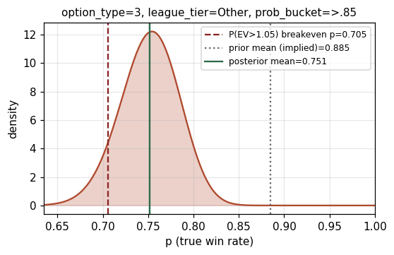

#### option_type=0, handicap_class=h2plus, prob_bucket=.55-.70

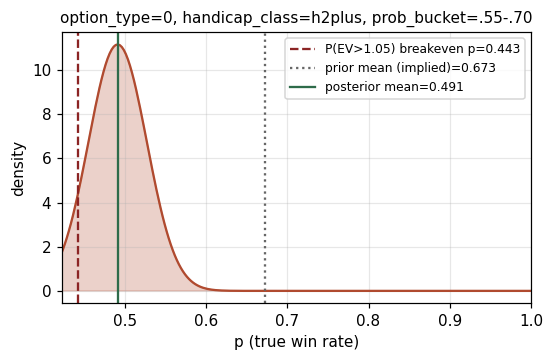

#### handicap_class=h2plus, league_tier=Other, prob_bucket=.55-.70

[figure not shown]

#### option_type=3, league_tier=LowerEU, prob_bucket=>.85

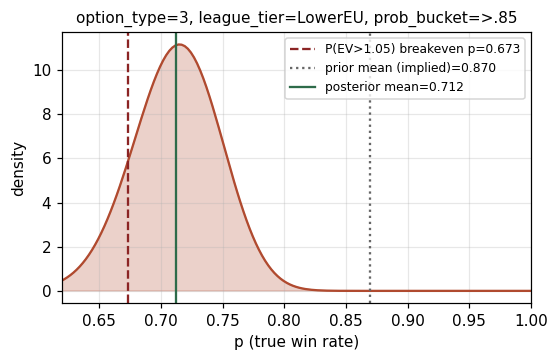

#### option_strength=fav, league_tier=Other, prob_bucket=>.85

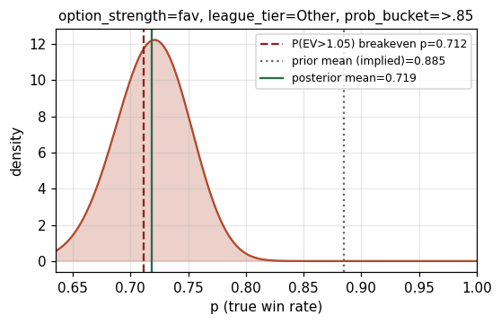